# Optimal Treatment Analysis

## Outcome Variable

**Outcome Variable:** haz

## Predictor Variables

**Intervention Variable:** mbmi

**Adjustment Set:**

- arm
- W_mage
- meducyrs
- feducyrs
- hhwealth_quart
- W_nrooms
- W_nchldlt5
- brthmon
- W_parity
- impfloor
- impsan
- safeh20
- delta_W_mage
- delta_meducyrs
- delta_feducyrs
- delta_hhwealth_quart
- delta_W_nrooms
- delta_W_nchldlt5
- delta_brthmon
- delta_W_parity
- delta_impfloor
- delta_impsan
- delta_safeh20

## Stratifying Variables

The analysis was stratified on these variable(s):

- agecat
- studyid
- country

## Data Summary

| agecat | studyid | country | mbmi | n_cell | n |
| --- | --- | --- | --- | --- | --- |
| Birth | ki0047075b-MAL-ED | BANGLADESH | Normal weight | 194 | 222 |
| Birth | ki0047075b-MAL-ED | BANGLADESH | Underweight | 28 | 222 |
| Birth | ki0047075b-MAL-ED | BRAZIL | Normal weight | 59 | 64 |
| Birth | ki0047075b-MAL-ED | BRAZIL | Underweight | 5 | 64 |
| Birth | ki0047075b-MAL-ED | INDIA | Normal weight | 35 | 43 |
| Birth | ki0047075b-MAL-ED | INDIA | Underweight | 8 | 43 |
| Birth | ki0047075b-MAL-ED | NEPAL | Normal weight | 27 | 27 |
| Birth | ki0047075b-MAL-ED | NEPAL | Underweight | 0 | 27 |
| Birth | ki0047075b-MAL-ED | PERU | Normal weight | 221 | 226 |
| Birth | ki0047075b-MAL-ED | PERU | Underweight | 5 | 226 |
| Birth | ki0047075b-MAL-ED | SOUTH AFRICA | Normal weight | 98 | 101 |
| Birth | ki0047075b-MAL-ED | SOUTH AFRICA | Underweight | 3 | 101 |
| Birth | ki0047075b-MAL-ED | TANZANIA, UNITED REPUBLIC OF | Normal weight | 115 | 122 |
| Birth | ki0047075b-MAL-ED | TANZANIA, UNITED REPUBLIC OF | Underweight | 7 | 122 |
| Birth | ki1000304b-SAS-CompFeed | INDIA | Normal weight | 830 | 1135 |
| Birth | ki1000304b-SAS-CompFeed | INDIA | Underweight | 305 | 1135 |
| Birth | ki1017093-NIH-Birth | BANGLADESH | Normal weight | 506 | 608 |
| Birth | ki1017093-NIH-Birth | BANGLADESH | Underweight | 102 | 608 |
| Birth | ki1017093b-PROVIDE | BANGLADESH | Normal weight | 418 | 517 |
| Birth | ki1017093b-PROVIDE | BANGLADESH | Underweight | 99 | 517 |
| Birth | ki1017093c-NIH-Crypto | BANGLADESH | Normal weight | 663 | 729 |
| Birth | ki1017093c-NIH-Crypto | BANGLADESH | Underweight | 66 | 729 |
| Birth | ki1119695-PROBIT | BELARUS | Normal weight | 13200 | 13723 |
| Birth | ki1119695-PROBIT | BELARUS | Underweight | 523 | 13723 |
| Birth | ki1126311-ZVITAMBO | ZIMBABWE | Normal weight | 9162 | 9672 |
| Birth | ki1126311-ZVITAMBO | ZIMBABWE | Underweight | 510 | 9672 |
| Birth | kiGH5241-JiVitA-3 | BANGLADESH | Normal weight | 16381 | 26546 |
| Birth | kiGH5241-JiVitA-3 | BANGLADESH | Underweight | 10165 | 26546 |
| 6 months | ki0047075b-MAL-ED | BANGLADESH | Normal weight | 209 | 241 |
| 6 months | ki0047075b-MAL-ED | BANGLADESH | Underweight | 32 | 241 |

[output cut: 60 more lines]

The following strata were considered:

- agecat: 24 months, studyid: ki0047075b-MAL-ED, country: BANGLADESH
- agecat: 24 months, studyid: ki0047075b-MAL-ED, country: BRAZIL
- agecat: 24 months, studyid: ki0047075b-MAL-ED, country: INDIA
- agecat: 24 months, studyid: ki0047075b-MAL-ED, country: NEPAL
- agecat: 24 months, studyid: ki0047075b-MAL-ED, country: PERU
- agecat: 24 months, studyid: ki0047075b-MAL-ED, country: SOUTH AFRICA
- agecat: 24 months, studyid: ki0047075b-MAL-ED, country: TANZANIA, UNITED REPUBLIC OF
- agecat: 24 months, studyid: ki1017093-NIH-Birth, country: BANGLADESH
- agecat: 24 months, studyid: ki1017093b-PROVIDE, country: BANGLADESH
- agecat: 24 months, studyid: ki1017093c-NIH-Crypto, country: BANGLADESH
- agecat: 24 months, studyid: ki1066203-TanzaniaChild2, country: TANZANIA, UNITED REPUBLIC OF
- agecat: 24 months, studyid: ki1119695-PROBIT, country: BELARUS
- agecat: 24 months, studyid: ki1126311-ZVITAMBO, country: ZIMBABWE
- agecat: 24 months, studyid: ki1148112-LCNI-5, country: MALAWI
- agecat: 24 months, studyid: kiGH5241-JiVitA-3, country: BANGLADESH
- agecat: 6 months, studyid: ki0047075b-MAL-ED, country: BANGLADESH
- agecat: 6 months, studyid: ki0047075b-MAL-ED, country: BRAZIL
- agecat: 6 months, studyid: ki0047075b-MAL-ED, country: INDIA
- agecat: 6 months, studyid: ki0047075b-MAL-ED, country: NEPAL
- agecat: 6 months, studyid: ki0047075b-MAL-ED, country: PERU
- agecat: 6 months, studyid: ki0047075b-MAL-ED, country: SOUTH AFRICA
- agecat: 6 months, studyid: ki0047075b-MAL-ED, country: TANZANIA, UNITED REPUBLIC OF
- agecat: 6 months, studyid: ki1000304b-SAS-CompFeed, country: INDIA
- agecat: 6 months, studyid: ki1017093-NIH-Birth, country: BANGLADESH
- agecat: 6 months, studyid: ki1017093b-PROVIDE, country: BANGLADESH
- agecat: 6 months, studyid: ki1017093c-NIH-Crypto, country: BANGLADESH
- agecat: 6 months, studyid: ki1066203-TanzaniaChild2, country: TANZANIA, UNITED REPUBLIC OF
- agecat: 6 months, studyid: ki1119695-PROBIT, country: BELARUS
- agecat: 6 months, studyid: ki1126311-ZVITAMBO, country: ZIMBABWE
- agecat: 6 months, studyid: ki1148112-LCNI-5, country: MALAWI
- agecat: 6 months, studyid: kiGH5241-JiVitA-3, country: BANGLADESH
- agecat: Birth, studyid: ki0047075b-MAL-ED, country: BANGLADESH
- agecat: Birth, studyid: ki0047075b-MAL-ED, country: BRAZIL
- agecat: Birth, studyid: ki0047075b-MAL-ED, country: INDIA
- agecat: Birth, studyid: ki0047075b-MAL-ED, country: NEPAL
- agecat: Birth, studyid: ki0047075b-MAL-ED, country: PERU
- agecat: Birth, studyid: ki0047075b-MAL-ED, country: SOUTH AFRICA
- agecat: Birth, studyid: ki0047075b-MAL-ED, country: TANZANIA, UNITED REPUBLIC OF
- agecat: Birth, studyid: ki1000304b-SAS-CompFeed, country: INDIA
- agecat: Birth, studyid: ki1017093-NIH-Birth, country: BANGLADESH
- agecat: Birth, studyid: ki1017093b-PROVIDE, country: BANGLADESH
- agecat: Birth, studyid: ki1017093c-NIH-Crypto, country: BANGLADESH
- agecat: Birth, studyid: ki1119695-PROBIT, country: BELARUS
- agecat: Birth, studyid: ki1126311-ZVITAMBO, country: ZIMBABWE
- agecat: Birth, studyid: kiGH5241-JiVitA-3, country: BANGLADESH

### Dropped Strata

Some strata were dropped due to rare outcomes:

- agecat: Birth, studyid: ki0047075b-MAL-ED, country: NEPAL
- agecat: Birth, studyid: ki0047075b-MAL-ED, country: SOUTH AFRICA
- agecat: 6 months, studyid: ki0047075b-MAL-ED, country: NEPAL
- agecat: 24 months, studyid: ki0047075b-MAL-ED, country: NEPAL
- agecat: 24 months, studyid: ki0047075b-MAL-ED, country: PERU
- agecat: 24 months, studyid: ki1066203-TanzaniaChild2, country: TANZANIA, UNITED REPUBLIC OF

## Methods Detail

We’re interested in the causal parameters $E[Y_a]$ for all values of $a \in \mathcal{A}$. These parameters represent the mean outcome if, possibly contrary to fact, we intervened to set all units to have $A=a$. Under the randomization and positivity assumptions, these are identified by the statistical parameters $\psi_a=E_W[E_{Y|A,W}(Y|A=a,W)]$. In addition, we’re interested in the mean of $Y$, $E[Y]$ under no intervention (the observed mean). We will estimate these parameters by using SuperLearner to fit the relevant likelihood factors – $E_{Y|A,W}(Y|A=a,W)$ and $p(A=a|W)$, and then updating our likelihood fit using a joint TMLE.

For unadjusted analyses ($W=\{\}$), initial likelihoods were estimated using Lrnr_glm to estimate the simple $E(Y|A)$ and Lrnr_mean to estimate $p(A)$. For adjusted analyses, a small library containing Lrnr_glmnet, Lrnr_xgboost, and Lrnr_mean was used.

Having estimated these parameters, we will then use the delta method to estimate relative risks and attributable risks relative to a prespecified baseline level of $A$.

# Results Detail

## Results Plots

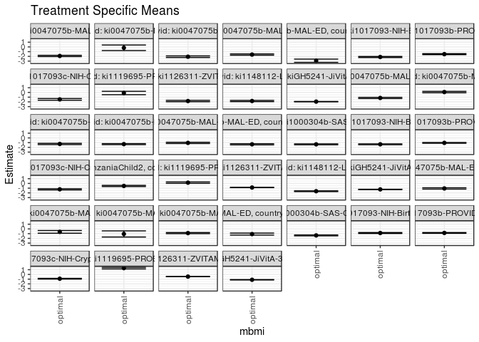

## Results Table

### Parameter: TSM

| agecat | studyid | country | intervention_level | baseline_level | estimate | ci_lower | ci_upper |
| --- | --- | --- | --- | --- | --- | --- | --- |
| Birth | ki0047075b-MAL-ED | BANGLADESH | optimal | observed | -1.0614304 | -1.2072291 | -0.9156317 |
| Birth | ki0047075b-MAL-ED | BRAZIL | optimal | observed | -0.6217877 | -0.9101459 | -0.3334296 |
| Birth | ki0047075b-MAL-ED | INDIA | optimal | observed | -1.0633056 | -1.7146600 | -0.4119511 |
| Birth | ki0047075b-MAL-ED | PERU | optimal | observed | -0.8868878 | -1.0065110 | -0.7672645 |
| Birth | ki0047075b-MAL-ED | TANZANIA, UNITED REPUBLIC OF | optimal | observed | -1.0937618 | -1.3086519 | -0.8788717 |
| Birth | ki1000304b-SAS-CompFeed | INDIA | optimal | observed | -1.3735982 | -1.4693848 | -1.2778115 |
| Birth | ki1017093-NIH-Birth | BANGLADESH | optimal | observed | -0.8660752 | -0.9616441 | -0.7705064 |
| Birth | ki1017093b-PROVIDE | BANGLADESH | optimal | observed | -0.8495785 | -0.9354568 | -0.7637002 |
| Birth | ki1017093c-NIH-Crypto | BANGLADESH | optimal | observed | -0.9074634 | -0.9889470 | -0.8259799 |
| Birth | ki1119695-PROBIT | BELARUS | optimal | observed | 1.3346477 | 1.1670231 | 1.5022723 |
| Birth | ki1126311-ZVITAMBO | ZIMBABWE | optimal | observed | -0.4611900 | -0.4862567 | -0.4361233 |
| Birth | kiGH5241-JiVitA-3 | BANGLADESH | optimal | observed | -1.1305996 | -1.1683722 | -1.0928270 |
| 6 months | ki0047075b-MAL-ED | BANGLADESH | optimal | observed | -1.1704941 | -1.2963616 | -1.0446267 |
| 6 months | ki0047075b-MAL-ED | BRAZIL | optimal | observed | 0.0751983 | -0.0738128 | 0.2242094 |
| 6 months | ki0047075b-MAL-ED | INDIA | optimal | observed | -1.2776965 | -1.4142551 | -1.1411378 |
| 6 months | ki0047075b-MAL-ED | PERU | optimal | observed | -1.3144061 | -1.4230676 | -1.2057447 |
| 6 months | ki0047075b-MAL-ED | SOUTH AFRICA | optimal | observed | -1.0476807 | -1.1786860 | -0.9166754 |
| 6 months | ki0047075b-MAL-ED | TANZANIA, UNITED REPUBLIC OF | optimal | observed | -1.3527236 | -1.4767305 | -1.2287167 |
| 6 months | ki1000304b-SAS-CompFeed | INDIA | optimal | observed | -1.3557066 | -1.4534862 | -1.2579269 |
| 6 months | ki1017093-NIH-Birth | BANGLADESH | optimal | observed | -1.3502483 | -1.4454102 | -1.2550864 |
| 6 months | ki1017093b-PROVIDE | BANGLADESH | optimal | observed | -1.0466974 | -1.1307058 | -0.9626890 |
| 6 months | ki1017093c-NIH-Crypto | BANGLADESH | optimal | observed | -1.2478177 | -1.3714697 | -1.1241657 |
| 6 months | ki1066203-TanzaniaChild2 | TANZANIA, UNITED REPUBLIC OF | optimal | observed | -0.5341738 | -0.6655027 | -0.4028449 |
| 6 months | ki1119695-PROBIT | BELARUS | optimal | observed | 0.1611796 | 0.0130668 | 0.3092924 |
| 6 months | ki1126311-ZVITAMBO | ZIMBABWE | optimal | observed | -0.8685350 | -0.8967231 | -0.8403470 |
| 6 months | ki1148112-LCNI-5 | MALAWI | optimal | observed | -1.6457246 | -1.7240810 | -1.5673683 |
| 6 months | kiGH5241-JiVitA-3 | BANGLADESH | optimal | observed | -1.2654826 | -1.2956202 | -1.2353449 |
| 24 months | ki0047075b-MAL-ED | BANGLADESH | optimal | observed | -1.9116977 | -2.0432806 | -1.7801147 |
| 24 months | ki0047075b-MAL-ED | BRAZIL | optimal | observed | -0.1849935 | -0.7739190 | 0.4039319 |
| 24 months | ki0047075b-MAL-ED | INDIA | optimal | observed | -2.0689501 | -2.2365655 | -1.9013346 |
| 24 months | ki0047075b-MAL-ED | SOUTH AFRICA | optimal | observed | -1.6175073 | -1.7556079 | -1.4794067 |
| 24 months | ki0047075b-MAL-ED | TANZANIA, UNITED REPUBLIC OF | optimal | observed | -2.9262980 | -3.2748671 | -2.5777290 |
| 24 months | ki1017093-NIH-Birth | BANGLADESH | optimal | observed | -2.1315810 | -2.2445319 | -2.0186301 |
| 24 months | ki1017093b-PROVIDE | BANGLADESH | optimal | observed | -1.5262201 | -1.6306225 | -1.4218178 |
| 24 months | ki1017093c-NIH-Crypto | BANGLADESH | optimal | observed | -1.4745981 | -1.6545374 | -1.2946589 |
| 24 months | ki1119695-PROBIT | BELARUS | optimal | observed | -0.1241022 | -0.4783064 | 0.2301021 |
| 24 months | ki1126311-ZVITAMBO | ZIMBABWE | optimal | observed | -1.8232202 | -1.9684346 | -1.6780058 |
| 24 months | ki1148112-LCNI-5 | MALAWI | optimal | observed | -1.8154890 | -1.9438441 | -1.6871338 |
| 24 months | kiGH5241-JiVitA-3 | BANGLADESH | optimal | observed | -1.9469723 | -1.9867703 | -1.9071742 |

### Parameter: E(Y)

| agecat | studyid | country | intervention_level | baseline_level | estimate | ci_lower | ci_upper |
| --- | --- | --- | --- | --- | --- | --- | --- |
| Birth | ki0047075b-MAL-ED | BANGLADESH | observed | observed | -1.0778829 | -1.2122580 | -0.9435077 |
| Birth | ki0047075b-MAL-ED | BRAZIL | observed | observed | -0.6884375 | -0.9678371 | -0.4090379 |
| Birth | ki0047075b-MAL-ED | INDIA | observed | observed | -1.2302326 | -1.5393614 | -0.9211037 |
| Birth | ki0047075b-MAL-ED | PERU | observed | observed | -0.9051327 | -1.0238686 | -0.7863969 |
| Birth | ki0047075b-MAL-ED | TANZANIA, UNITED REPUBLIC OF | observed | observed | -1.1364754 | -1.3478823 | -0.9250686 |
| Birth | ki1000304b-SAS-CompFeed | INDIA | observed | observed | -1.4438150 | -1.5337502 | -1.3538797 |
| Birth | ki1017093-NIH-Birth | BANGLADESH | observed | observed | -0.9310197 | -1.0197391 | -0.8423003 |
| Birth | ki1017093b-PROVIDE | BANGLADESH | observed | observed | -0.8925145 | -0.9687201 | -0.8163089 |
| Birth | ki1017093c-NIH-Crypto | BANGLADESH | observed | observed | -0.9089163 | -0.9806324 | -0.8372002 |
| Birth | ki1119695-PROBIT | BELARUS | observed | observed | 1.3271449 | 1.1680455 | 1.4862444 |
| Birth | ki1126311-ZVITAMBO | ZIMBABWE | observed | observed | -0.4764413 | -0.5009156 | -0.4519670 |
| Birth | kiGH5241-JiVitA-3 | BANGLADESH | observed | observed | -1.1727085 | -1.2008532 | -1.1445639 |
| 6 months | ki0047075b-MAL-ED | BANGLADESH | observed | observed | -1.2054910 | -1.3228953 | -1.0880867 |
| 6 months | ki0047075b-MAL-ED | BRAZIL | observed | observed | 0.0532131 | -0.0914567 | 0.1978830 |
| 6 months | ki0047075b-MAL-ED | INDIA | observed | observed | -1.2058014 | -1.3242792 | -1.0873236 |
| 6 months | ki0047075b-MAL-ED | PERU | observed | observed | -1.3285478 | -1.4371840 | -1.2199116 |
| 6 months | ki0047075b-MAL-ED | SOUTH AFRICA | observed | observed | -1.0733534 | -1.2031913 | -0.9435155 |
| 6 months | ki0047075b-MAL-ED | TANZANIA, UNITED REPUBLIC OF | observed | observed | -1.3687449 | -1.4907629 | -1.2467270 |
| 6 months | ki1000304b-SAS-CompFeed | INDIA | observed | observed | -1.4068893 | -1.4981242 | -1.3156543 |
| 6 months | ki1017093-NIH-Birth | BANGLADESH | observed | observed | -1.4073821 | -1.4960598 | -1.3187043 |
| 6 months | ki1017093b-PROVIDE | BANGLADESH | observed | observed | -1.0895301 | -1.1639589 | -1.0151013 |
| 6 months | ki1017093c-NIH-Crypto | BANGLADESH | observed | observed | -1.1986783 | -1.2700937 | -1.1272630 |
| 6 months | ki1066203-TanzaniaChild2 | TANZANIA, UNITED REPUBLIC OF | observed | observed | -0.5405711 | -0.5899965 | -0.4911457 |
| 6 months | ki1119695-PROBIT | BELARUS | observed | observed | 0.1153731 | 0.0222128 | 0.2085334 |
| 6 months | ki1126311-ZVITAMBO | ZIMBABWE | observed | observed | -0.8800508 | -0.9074511 | -0.8526506 |
| 6 months | ki1148112-LCNI-5 | MALAWI | observed | observed | -1.6577751 | -1.7275296 | -1.5880207 |
| 6 months | kiGH5241-JiVitA-3 | BANGLADESH | observed | observed | -1.3365058 | -1.3595555 | -1.3134561 |
| 24 months | ki0047075b-MAL-ED | BANGLADESH | observed | observed | -1.9789151 | -2.1055330 | -1.8522972 |
| 24 months | ki0047075b-MAL-ED | BRAZIL | observed | observed | 0.0069048 | -0.1627841 | 0.1765936 |
| 24 months | ki0047075b-MAL-ED | INDIA | observed | observed | -1.8831195 | -2.0084753 | -1.7577636 |
| 24 months | ki0047075b-MAL-ED | SOUTH AFRICA | observed | observed | -1.6474145 | -1.7842298 | -1.5105993 |
| 24 months | ki0047075b-MAL-ED | TANZANIA, UNITED REPUBLIC OF | observed | observed | -2.6451636 | -2.7802323 | -2.5100948 |
| 24 months | ki1017093-NIH-Birth | BANGLADESH | observed | observed | -2.2190579 | -2.3217459 | -2.1163699 |
| 24 months | ki1017093b-PROVIDE | BANGLADESH | observed | observed | -1.6002600 | -1.6836163 | -1.5169036 |
| 24 months | ki1017093c-NIH-Crypto | BANGLADESH | observed | observed | -1.4412646 | -1.5249156 | -1.3576135 |
| 24 months | ki1119695-PROBIT | BELARUS | observed | observed | -0.1322181 | -0.4300523 | 0.1656161 |
| 24 months | ki1126311-ZVITAMBO | ZIMBABWE | observed | observed | -1.5983212 | -1.6605141 | -1.5361283 |
| 24 months | ki1148112-LCNI-5 | MALAWI | observed | observed | -1.8851820 | -1.9664818 | -1.8038822 |
| 24 months | kiGH5241-JiVitA-3 | BANGLADESH | observed | observed | -2.0196953 | -2.0474028 | -1.9919877 |

### Parameter: PAR

| agecat | studyid | country | intervention_level | baseline_level | estimate | ci_lower | ci_upper |
| --- | --- | --- | --- | --- | --- | --- | --- |
| Birth | ki0047075b-MAL-ED | BANGLADESH | optimal | observed | -0.0164525 | -0.0614474 | 0.0285424 |
| Birth | ki0047075b-MAL-ED | BRAZIL | optimal | observed | -0.0666498 | -0.1549263 | 0.0216267 |
| Birth | ki0047075b-MAL-ED | INDIA | optimal | observed | -0.1669270 | -0.7888540 | 0.4550000 |
| Birth | ki0047075b-MAL-ED | PERU | optimal | observed | -0.0182450 | -0.0406854 | 0.0041955 |
| Birth | ki0047075b-MAL-ED | TANZANIA, UNITED REPUBLIC OF | optimal | observed | -0.0427136 | -0.1055154 | 0.0200881 |
| Birth | ki1000304b-SAS-CompFeed | INDIA | optimal | observed | -0.0702168 | -0.0932117 | -0.0472220 |
| Birth | ki1017093-NIH-Birth | BANGLADESH | optimal | observed | -0.0649445 | -0.1072826 | -0.0226064 |
| Birth | ki1017093b-PROVIDE | BANGLADESH | optimal | observed | -0.0429360 | -0.0816129 | -0.0042591 |
| Birth | ki1017093c-NIH-Crypto | BANGLADESH | optimal | observed | -0.0014529 | -0.0365354 | 0.0336296 |
| Birth | ki1119695-PROBIT | BELARUS | optimal | observed | -0.0075028 | -0.0278602 | 0.0128547 |
| Birth | ki1126311-ZVITAMBO | ZIMBABWE | optimal | observed | -0.0152513 | -0.0213219 | -0.0091806 |
| Birth | kiGH5241-JiVitA-3 | BANGLADESH | optimal | observed | -0.0421089 | -0.0671537 | -0.0170642 |
| 6 months | ki0047075b-MAL-ED | BANGLADESH | optimal | observed | -0.0349969 | -0.0799578 | 0.0099641 |
| 6 months | ki0047075b-MAL-ED | BRAZIL | optimal | observed | -0.0219851 | -0.0470525 | 0.0030822 |
| 6 months | ki0047075b-MAL-ED | INDIA | optimal | observed | 0.0718950 | -0.0163984 | 0.1601885 |
| 6 months | ki0047075b-MAL-ED | PERU | optimal | observed | -0.0141417 | -0.0383785 | 0.0100952 |
| 6 months | ki0047075b-MAL-ED | SOUTH AFRICA | optimal | observed | -0.0256727 | -0.0513999 | 0.0000545 |
| 6 months | ki0047075b-MAL-ED | TANZANIA, UNITED REPUBLIC OF | optimal | observed | -0.0160214 | -0.0516208 | 0.0195780 |
| 6 months | ki1000304b-SAS-CompFeed | INDIA | optimal | observed | -0.0511827 | -0.0888962 | -0.0134692 |
| 6 months | ki1017093-NIH-Birth | BANGLADESH | optimal | observed | -0.0571338 | -0.1005085 | -0.0137591 |
| 6 months | ki1017093b-PROVIDE | BANGLADESH | optimal | observed | -0.0428327 | -0.0758335 | -0.0098320 |
| 6 months | ki1017093c-NIH-Crypto | BANGLADESH | optimal | observed | 0.0491394 | -0.0514523 | 0.1497310 |
| 6 months | ki1066203-TanzaniaChild2 | TANZANIA, UNITED REPUBLIC OF | optimal | observed | -0.0063973 | -0.1259182 | 0.1131236 |
| 6 months | ki1119695-PROBIT | BELARUS | optimal | observed | -0.0458066 | -0.1397629 | 0.0481498 |
| 6 months | ki1126311-ZVITAMBO | ZIMBABWE | optimal | observed | -0.0115158 | -0.0177910 | -0.0052407 |
| 6 months | ki1148112-LCNI-5 | MALAWI | optimal | observed | -0.0120505 | -0.0421286 | 0.0180276 |
| 6 months | kiGH5241-JiVitA-3 | BANGLADESH | optimal | observed | -0.0710232 | -0.0913666 | -0.0506799 |
| 24 months | ki0047075b-MAL-ED | BANGLADESH | optimal | observed | -0.0672174 | -0.1240164 | -0.0104184 |
| 24 months | ki0047075b-MAL-ED | BRAZIL | optimal | observed | 0.1918983 | -0.3540424 | 0.7378390 |
| 24 months | ki0047075b-MAL-ED | INDIA | optimal | observed | 0.1858306 | 0.0690713 | 0.3025899 |
| 24 months | ki0047075b-MAL-ED | SOUTH AFRICA | optimal | observed | -0.0299072 | -0.0582824 | -0.0015321 |
| 24 months | ki0047075b-MAL-ED | TANZANIA, UNITED REPUBLIC OF | optimal | observed | 0.2811345 | -0.0446311 | 0.6069001 |
| 24 months | ki1017093-NIH-Birth | BANGLADESH | optimal | observed | -0.0874769 | -0.1367286 | -0.0382251 |
| 24 months | ki1017093b-PROVIDE | BANGLADESH | optimal | observed | -0.0740398 | -0.1416203 | -0.0064594 |
| 24 months | ki1017093c-NIH-Crypto | BANGLADESH | optimal | observed | 0.0333336 | -0.1225998 | 0.1892669 |
| 24 months | ki1119695-PROBIT | BELARUS | optimal | observed | -0.0081159 | -0.2314058 | 0.2151740 |
| 24 months | ki1126311-ZVITAMBO | ZIMBABWE | optimal | observed | 0.2248990 | 0.0897893 | 0.3600087 |
| 24 months | ki1148112-LCNI-5 | MALAWI | optimal | observed | -0.0696930 | -0.1711273 | 0.0317413 |
| 24 months | kiGH5241-JiVitA-3 | BANGLADESH | optimal | observed | -0.0727230 | -0.1020829 | -0.0433631 |